# hw02_dplyr

## **Exercise 1: Basic dplyr**

*Loading packages*

```r
library(dplyr)
library(gapminder)
```

### **1.1**

```r
gapminder %>%
  filter(year < 1980 & year > 1969,
         country %in% c("Canada", "Spain", "Portugal")) %>%
  knitr::kable()
```

| country | continent | year | lifeExp | pop | gdpPercap |
| --- | --- | --- | --- | --- | --- |
| Canada | Americas | 1972 | 72.88 | 22284500 | 18970.571 |
| Canada | Americas | 1977 | 74.21 | 23796400 | 22090.883 |
| Portugal | Europe | 1972 | 69.26 | 8970450 | 9022.247 |
| Portugal | Europe | 1977 | 70.41 | 9662600 | 10172.486 |
| Spain | Europe | 1972 | 73.06 | 34513161 | 10638.751 |
| Spain | Europe | 1977 | 74.39 | 36439000 | 13236.921 |

### **1.2**

```r
gapminder %>%
  filter(year < 1980 & year > 1969,
         country %in% c("Canada", "Spain", "Portugal")) %>%
  select(country, gdpPercap) %>%
  knitr::kable()
```

| country | gdpPercap |
| --- | --- |
| Canada | 18970.571 |
| Canada | 22090.883 |
| Portugal | 9022.247 |
| Portugal | 10172.486 |
| Spain | 10638.751 |
| Spain | 13236.921 |

### **1.3**

```r
gapminder %>%
  group_by(country) %>%
  select(country, year, lifeExp) %>%
  mutate(lifeExp_increase = lifeExp - lag(lifeExp)) %>%
  arrange(lifeExp_increase) %>%
  filter(lifeExp_increase < 0) %>%
  DT::datatable()
```

|  | country | year | lifeExp | lifeExp_increase |
| --- | --- | --- | --- | --- |
| 1 | Rwanda | 1992 | 23.599 | -20.421 |
| 2 | Zimbabwe | 1997 | 46.809 | -13.568 |
| 3 | Lesotho | 2002 | 44.593 | -10.965 |
| 4 | Swaziland | 2002 | 43.869 | -10.42 |
| 5 | Botswana | 1997 | 52.556 | -10.189 |
| 6 | Cambodia | 1977 | 31.22 | -9.097 |
| 7 | Namibia | 2002 | 51.479 | -7.43 |
| 8 | South Africa | 2002 | 53.365 | -6.871 |
| 9 | Zimbabwe | 2002 | 39.989 | -6.82 |
| 10 | China | 1962 | 44.50136 | -6.0476 |

[output cut: 92 more lines]

### **1.4**

```r
gapminder %>%
  group_by(country) %>%
  summarize(maxGdpPercap = max(gdpPercap)) %>%
  DT::datatable()
```

|  | country | maxGdpPercap |
| --- | --- | --- |
| 1 | Afghanistan | 978.0114388 |
| 2 | Albania | 5937.029526 |
| 3 | Algeria | 6223.367465 |
| 4 | Angola | 5522.776375 |
| 5 | Argentina | 12779.37964 |
| 6 | Australia | 34435.36744 |
| 7 | Austria | 36126.4927 |
| 8 | Bahrain | 29796.04834 |
| 9 | Bangladesh | 1391.253792 |
| 10 | Belgium | 33692.60508 |

[output cut: 132 more lines]

### **1.5**

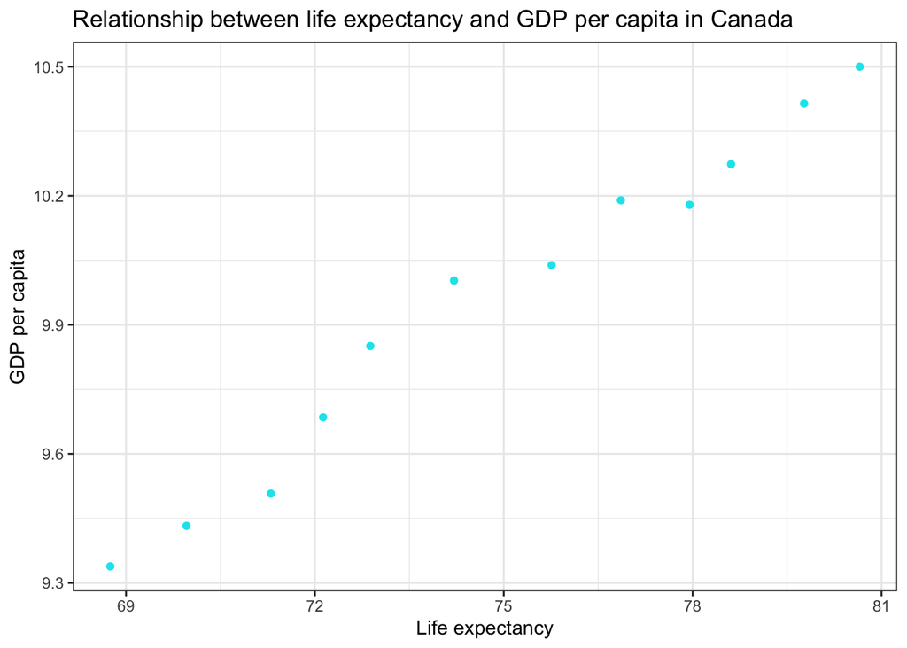

```r
library(ggplot2)

gapminder %>%
  filter(country == "Canada",
         lifeExp, gdpPercap) %>%
  mutate(gdpPercap_log = log(gdpPercap)) %>%
  ggplot(aes(lifeExp, gdpPercap_log)) +
  geom_point(colour="turquoise2") +
  xlab("Life expectancy") +
  ylab("GDP per capita") +
  ggtitle("Relationship between life expectancy and GDP per capita in Canada") +
  theme_bw()
```

## **Exercise 2: Explore individual variables with dplyr**

Pick one categorical variable and one quantitative variable to explore. Answer the following questions in whichever way you think is appropriate, using dplyr:

What are possible values (or range, whichever is appropriate) of each variable? What values are typical? What’s the spread? What’s the distribution? Etc., tailored to the variable at hand.

Feel free to use summary stats, tables, figures.

```r
library(tidyverse)
#exploring categorical variable: type of cars
mtcars %>%
  rownames_to_column("type") %>%
  distinct(type) %>%
  filter(stringr::str_detect(type, "Toyota")) %>% #looking for Toyota models in the dataset
  knitr::kable()
```

| type |
| --- |
| Toyota Corolla |
| Toyota Corona |

```r
mtcars %>%
  rownames_to_column("type") %>%
  group_by("type") %>%
  filter(mpg > 30 & hp > 50) %>% #finding all cars with mpg above 30 and hp above 50
  arrange(desc(mpg, hp)) %>%
  mutate(relationship_mpg_hp = mpg * hp) %>%
  knitr::kable()
```

| type | mpg | cyl | disp | hp | drat | wt | qsec | vs | am | gear | carb | “type” | relationship_mpg_hp |
| --- | --- | --- | --- | --- | --- | --- | --- | --- | --- | --- | --- | --- | --- |
| Toyota Corolla | 33.9 | 4 | 71.1 | 65 | 4.22 | 1.835 | 19.90 | 1 | 1 | 4 | 1 | type | 2203.5 |
| Fiat 128 | 32.4 | 4 | 78.7 | 66 | 4.08 | 2.200 | 19.47 | 1 | 1 | 4 | 1 | type | 2138.4 |
| Honda Civic | 30.4 | 4 | 75.7 | 52 | 4.93 | 1.615 | 18.52 | 1 | 1 | 4 | 2 | type | 1580.8 |
| Lotus Europa | 30.4 | 4 | 95.1 | 113 | 3.77 | 1.513 | 16.90 | 1 | 1 | 5 | 2 | type | 3435.2 |

```r
#exploring numerical variable: year
gapminder %>%
  distinct(year) %>% #all the values for this variable
  knitr::kable()
```

| year |
| --- |
| 1952 |
| 1957 |
| 1962 |
| 1967 |
| 1972 |
| 1977 |
| 1982 |
| 1987 |
| 1992 |
| 1997 |
| 2002 |
| 2007 |

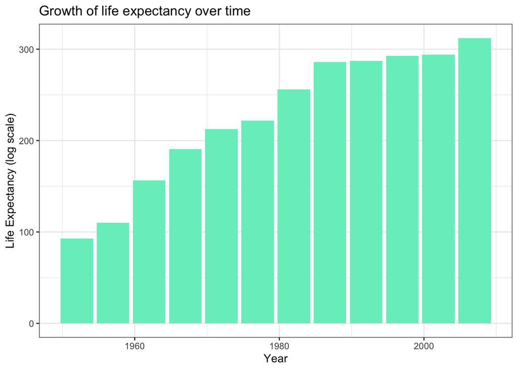

```r
gapminder %>%
  filter(lifeExp > 60, gdpPercap > 5000) %>% #interested in countries with lifeExp > 60 and gdpPercap > 5000
    group_by(year) %>%
  arrange(desc(year)) %>%
    select(-c(country, pop, gdpPercap)) %>% #getting rid of columns that I am not interested in
  ggplot(aes(year, log(lifeExp))) +
  geom_bar(stat="identity", fill = "aquamarine2") +
  xlab("Year") +
  ylab("Life Expectancy (log scale)") +
  ggtitle("Growth of life expectancy over time") +
  theme_bw()
```

## **Exercise 3: Explore various plot types**

```r
library(ggplot2)

DT::datatable(datasets::faithful)
```

|  | eruptions | waiting |
| --- | --- | --- |
| 1 | 3.6 | 79 |
| 2 | 1.8 | 54 |
| 3 | 3.333 | 74 |
| 4 | 2.283 | 62 |
| 5 | 4.533 | 85 |
| 6 | 2.883 | 55 |
| 7 | 4.7 | 88 |
| 8 | 3.6 | 85 |
| 9 | 1.95 | 51 |
| 10 | 4.35 | 85 |

[output cut: 262 more lines]

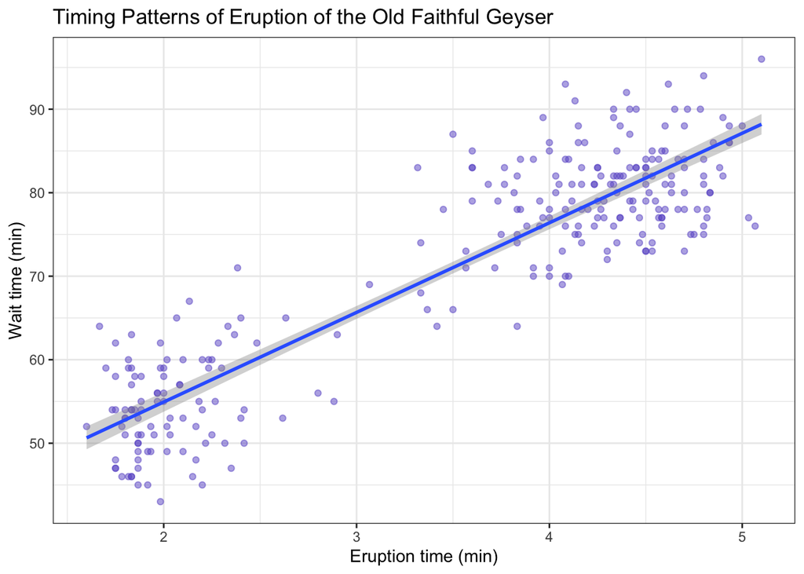

```r
faithful %>%
  ggplot(aes(eruptions, waiting)) +
  xlab("Eruption time (min)") +
  ylab("Wait time (min)") +
  ggtitle("Timing Patterns of Eruption of the Old Faithful Geyser") +
  geom_point(alpha = 0.5, colour = "slateblue3") +
  geom_smooth(method = "lm") +
  theme_bw()
```

```r
DT::datatable(datasets::mtcars)
```

|  | mpg | cyl | disp | hp | drat | wt | qsec | vs | am | gear | carb |
| --- | --- | --- | --- | --- | --- | --- | --- | --- | --- | --- | --- |
| Mazda RX4 | 21 | 6 | 160 | 110 | 3.9 | 2.62 | 16.46 | 0 | 1 | 4 | 4 |
| Mazda RX4 Wag | 21 | 6 | 160 | 110 | 3.9 | 2.875 | 17.02 | 0 | 1 | 4 | 4 |
| Datsun 710 | 22.8 | 4 | 108 | 93 | 3.85 | 2.32 | 18.61 | 1 | 1 | 4 | 1 |
| Hornet 4 Drive | 21.4 | 6 | 258 | 110 | 3.08 | 3.215 | 19.44 | 1 | 0 | 3 | 1 |
| Hornet Sportabout | 18.7 | 8 | 360 | 175 | 3.15 | 3.44 | 17.02 | 0 | 0 | 3 | 2 |
| Valiant | 18.1 | 6 | 225 | 105 | 2.76 | 3.46 | 20.22 | 1 | 0 | 3 | 1 |
| Duster 360 | 14.3 | 8 | 360 | 245 | 3.21 | 3.57 | 15.84 | 0 | 0 | 3 | 4 |
| Merc 240D | 24.4 | 4 | 146.7 | 62 | 3.69 | 3.19 | 20 | 1 | 0 | 4 | 2 |
| Merc 230 | 22.8 | 4 | 140.8 | 95 | 3.92 | 3.15 | 22.9 | 1 | 0 | 4 | 2 |
| Merc 280 | 19.2 | 6 | 167.6 | 123 | 3.92 | 3.44 | 18.3 | 1 | 0 | 4 | 4 |

[output cut: 22 more lines]

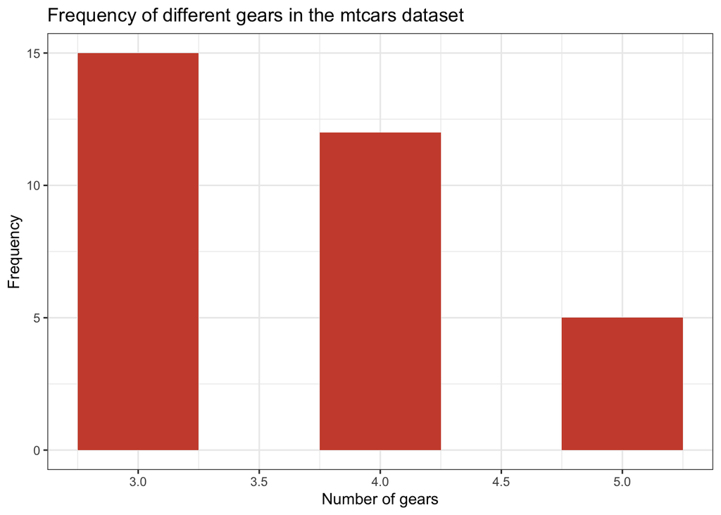

```r
mtcars %>%
  ggplot(aes(gear,)) +
  geom_bar(width = 0.5, fill = "tomato3") +
  xlab("Number of gears") +
  ylab("Frequency") +
  ggtitle("Frequency of different gears in the mtcars dataset") +
  theme_bw()
```